# Introduction to Deep Learning in R - Part 1

D-Lab

11/24/2018 (updated: 2019-03-19)

## Introduction

[Review the slides to get onboarded](https://dlab-berkeley.github.io/Deep-Learning-in-R/slides.html#1)

## Install packages

Run this chunk manually to install once. It will not be run when one clicks “knit” or “run all”.

```r
# Install keras package from CRAN.
install.packages("keras")

# If the most recent version is desired:
# devtools::install_github("rstudio/keras")

# Then run install_keras() function to install anaconda python, tensorflow, and keras.
keras::install_keras()
# Or if you have a GPU and have followed these instructions:
# https://tensorflow.rstudio.com/tools/local_gpu.html
# NOTE: tensorflow seems to require CUDA 9.0 currently; 9.2 for example will not work.
# keras::install_keras(tensorflow = "gpu")
```

Also install some other helper packages. Run this line manually if needed:

```r
install.packages(c("cowplot", "dplyr", "ggplot2"))
```

## Load packages

Now that we have installed the necessary packages, library them so that R can utilize their functionalities

```r
library(cowplot)
library(keras)
library(dplyr)
library(tensorflow)
library(ggplot2)
```

## MNIST handwritten digit example

Jump in! The first example will consist of a walkthrough of the Keras vignette [located here](https://cran.r-project.org/web/packages/keras/vignettes/getting_started.html).

Let’s look at 70,000 handwritten digit images from the [Modified National Institute of Standards and Technology database](https://en.wikipedia.org/wiki/MNIST_database) (MNIST).

```r
# This line requires a working internet connection to download the data the first time.
mnist = dataset_mnist()

# How are the data stored?
str(mnist)
```

```
## List of 2
##  $ train:List of 2
##   ..$ x: int [1:60000, 1:28, 1:28] 0 0 0 0 0 0 0 0 0 0 ...
##   ..$ y: int [1:60000(1d)] 5 0 4 1 9 2 1 3 1 4 ...
##  $ test :List of 2
##   ..$ x: int [1:10000, 1:28, 1:28] 0 0 0 0 0 0 0 0 0 0 ...
##   ..$ y: int [1:10000(1d)] 7 2 1 0 4 1 4 9 5 9 ...
```

```r
# Define our x and y variables for the training and test sets.
x_train = mnist$train$x
y_train = mnist$train$y
x_test = mnist$test$x
y_test = mnist$test$y

# Note the 3D array structure of the raw features
str(x_train)
```

```
##  int [1:60000, 1:28, 1:28] 0 0 0 0 0 0 0 0 0 0 ...
```

```r
str(x_test)
```

```
##  int [1:10000, 1:28, 1:28] 0 0 0 0 0 0 0 0 0 0 ...
```

## Reshape, rescale, one-hot encode

### X variables

The `array_reshape` function allows us to reshape a three-dimensional array like those foudn in our `mnist` dataset into matrices. Our 28x28 pixel images will become arrays/vectors with length $28*28 = 784$.

```r
height = 28
width = 28

# Reshape
x_train = array_reshape(x_train, c(nrow(x_train), height * width))
x_test = array_reshape(x_test, c(nrow(x_test), height * width))

# Check the new 2D feature dimensions
str(x_train)
```

```
##  int [1:60000, 1:784] 0 0 0 0 0 0 0 0 0 0 ...
```

```r
str(x_test)
```

```
##  int [1:10000, 1:784] 0 0 0 0 0 0 0 0 0 0 ...
```

### Gray rescale

Grayscale pixel values that range from between 0 (black end of the color spectrum) to 255 (white end of the color spectrum) are scaled to values between 0 and 1. The model will use these binary matrices to help determine the shape of the image from a pixelated perspective.

```r
# rescale
x_train = x_train / 255
x_test = x_test / 255
```

### Y variables

We also want to convert our y outcome vector to a one-hot encoded binary matrix. We specify 10 because we have 10 numbers (0 thru 9). Type `?to_categorical` to learn more.

```r
# Convert our outcome and specify 10 possible classes.
y_train = to_categorical(y_train, 10)
y_test = to_categorical(y_test, 10)

# Check dimensions of new y matrices.
dim(y_train)
```

```
## [1] 60000    10
```

```r
dim(y_test)
```

```
## [1] 10000    10
```

```r
# Review percentage of obervations with each digit label.
round(colMeans(y_train), 3)
```

```
##  [1] 0.099 0.112 0.099 0.102 0.097 0.090 0.099 0.104 0.098 0.099
```

```r
round(colMeans(y_test), 3)
```

```
##  [1] 0.098 0.114 0.103 0.101 0.098 0.089 0.096 0.103 0.097 0.101
```

Or, see the data in its entirety of 0’s and 1’s. How do the dimensions of these matrices relate to your `dim` calls above?

```r
View(y_train)
View(y_test)
```

## Define the model

Now we can define the model! We just want to build a linear stack of layers. The `units` parameter defines how many nodes we should have in each layer. `input_shape` allows us to define the image dimensions. The `activation` parameter allows us to pass in the name of an activation function as the argument.

See `?keras_model_sequential` to learn more.

```r
model = keras_model_sequential()

model %>%

  # INPUT LAYER + 1st HIDDEN LAYER.
  # layer_dense allows us to add a layer! What parameters are we specifying?

  layer_dense(units = 256, activation = 'relu', input_shape = c(784)) %>%

  layer_dropout(rate = 0.4) %>%

  # HIDDEN LAYER  (2nd)
  layer_dense(units = 128, activation = 'relu') %>%

  layer_dropout(rate = 0.3) %>%

  # OUTPUT LAYER
  layer_dense(units = 10, activation = 'softmax')

summary(model)
```

```
## ___________________________________________________________________________
## Layer (type)                     Output Shape                  Param #
## ===========================================================================
## dense_1 (Dense)                  (None, 256)                   200960
## ___________________________________________________________________________
## dropout_1 (Dropout)              (None, 256)                   0
## ___________________________________________________________________________
## dense_2 (Dense)                  (None, 128)                   32896
## ___________________________________________________________________________
## dropout_2 (Dropout)              (None, 128)                   0
## ___________________________________________________________________________
## dense_3 (Dense)                  (None, 10)                    1290
## ===========================================================================
## Total params: 235,146
## Trainable params: 235,146
## Non-trainable params: 0
## ___________________________________________________________________________
```

## Compile model with loss function, optimizer, and metrics

Recall that loss and optimizer functions work in tandem to tell us how wrong our predictions are.

We define “categorical_crossentropy” as our loss function since we are dealing with multilevel classification, and “optimizer_rmsprop()” as our optimizer because it might perform a little bit better than gradient descent with momentum. What does the `lr` parameter do? We also select “accuracy” as our metric to produce simple classification rates for our outcomes.

```r
model %>% compile(
  loss = 'categorical_crossentropy',
  optimizer = optimizer_rmsprop(lr = 0.001),
  metrics = c('accuracy')
)
```

## Train and evaluate

Now we can train the model using `fit`! Here, we can just pass in our X and Y variables along with the other hyperparameters.

Watch the model build epoch by epoch.

```r
set.seed(1)
history = model %>% fit(
  x_train, y_train,
  epochs = 30, batch_size = 128,
  validation_split = 0.2
)
```

### Interpreting the plot

**loss**: loss is the mean of the average loss across each batch of training data. We expect that the loss for earlier batches is higher than that for later batches because the model *should* be learning over time. We hope that the later batches of data have lower losses.

**acc**: is the training accuracy.

## Plot history via ggplot

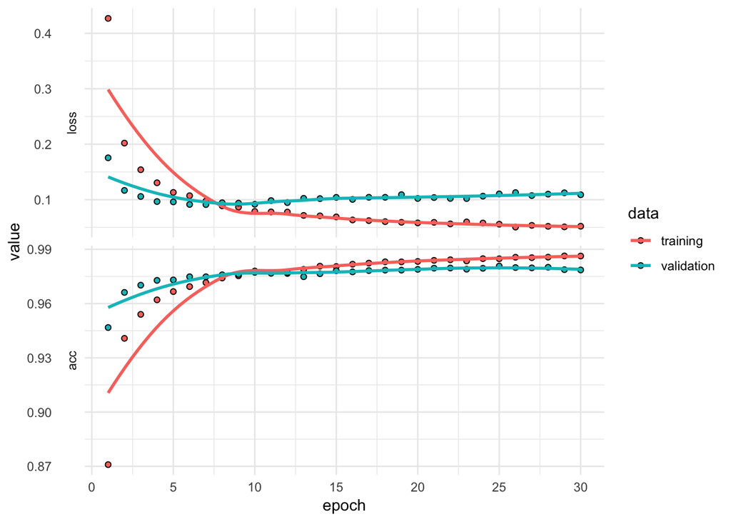

```r
plot(history) + theme_minimal()
```

## Evaluate performance on the test data

```r
model %>% evaluate(x_test, y_test)
```

```
## $loss
## [1] 0.1012978
##
## $acc
## [1] 0.98
```

```r
# The model works pretty well!
```

## Challenge

Write down the steps you followed to run this model from start to finish. What does each part do?